# Boosting

# Setup

```python
import pandas as pd
import numpy as np
import matplotlib.pyplot as plt
import seaborn as sns

import catboost as cat
import lightgbm as lgb
import xgboost  as xgb
from sklearn.ensemble import AdaBoostClassifier
from sklearn.ensemble import AdaBoostRegressor

from sklearn.pipeline import Pipeline
from sklearn.preprocessing import OneHotEncoder
from sklearn.preprocessing import LabelEncoder
from sklearn.impute import SimpleImputer
from sklearn.preprocessing import StandardScaler
from sklearn.compose import ColumnTransformer

from sklearn.model_selection import train_test_split
from sklearn.metrics import classification_report
from sklearn.metrics import confusion_matrix
from sklearn.metrics import log_loss
from sklearn.metrics import accuracy_score

from yellowbrick.classifier import ClassificationReport
from yellowbrick.classifier import ClassPredictionError
from yellowbrick.classifier import ConfusionMatrix
```

```python
#!conda install lightgbm --yes
```

# Data

- Kaggle 2015 Flight Delays (https://www.kaggle.com/usdot/flight-delays/downloads/flight-delays.zip/1)

```python
flightDF  = pd.read_csv('./flight-delays/flights.csv')
airportDF = pd.read_csv('./flight-delays/airports.csv')
airlineDF = pd.read_csv('./flight-delays/airlines.csv')
```

```python
flightDF.dtypes
```

```
YEAR                     int64
MONTH                    int64
DAY                      int64
DAY_OF_WEEK              int64
AIRLINE                 object
FLIGHT_NUMBER            int64
TAIL_NUMBER             object
ORIGIN_AIRPORT          object
DESTINATION_AIRPORT     object
SCHEDULED_DEPARTURE      int64
DEPARTURE_TIME         float64
DEPARTURE_DELAY        float64
TAXI_OUT               float64
WHEELS_OFF             float64
SCHEDULED_TIME         float64
ELAPSED_TIME           float64
AIR_TIME               float64
DISTANCE                 int64
WHEELS_ON              float64
TAXI_IN                float64
SCHEDULED_ARRIVAL        int64
ARRIVAL_TIME           float64
ARRIVAL_DELAY          float64
DIVERTED                 int64
CANCELLED                int64
CANCELLATION_REASON     object
AIR_SYSTEM_DELAY       float64
SECURITY_DELAY         float64
AIRLINE_DELAY          float64
LATE_AIRCRAFT_DELAY    float64
WEATHER_DELAY          float64
dtype: object
```

```python
flightDF.head()
```

|  | YEAR | MONTH | DAY | DAY_OF_WEEK | AIRLINE | FLIGHT_NUMBER | TAIL_NUMBER | ORIGIN_AIRPORT | DESTINATION_AIRPORT | SCHEDULED_DEPARTURE | ... | ARRIVAL_TIME | ARRIVAL_DELAY | DIVERTED | CANCELLED | CANCELLATION_REASON | AIR_SYSTEM_DELAY | SECURITY_DELAY | AIRLINE_DELAY | LATE_AIRCRAFT_DELAY | WEATHER_DELAY |
| --- | --- | --- | --- | --- | --- | --- | --- | --- | --- | --- | --- | --- | --- | --- | --- | --- | --- | --- | --- | --- | --- |
| 0 | 2015 | 1 | 1 | 4 | AS | 98 | N407AS | ANC | SEA | 5 | ... | 408.0 | -22.0 | 0 | 0 | NaN | NaN | NaN | NaN | NaN | NaN |
| 1 | 2015 | 1 | 1 | 4 | AA | 2336 | N3KUAA | LAX | PBI | 10 | ... | 741.0 | -9.0 | 0 | 0 | NaN | NaN | NaN | NaN | NaN | NaN |
| 2 | 2015 | 1 | 1 | 4 | US | 840 | N171US | SFO | CLT | 20 | ... | 811.0 | 5.0 | 0 | 0 | NaN | NaN | NaN | NaN | NaN | NaN |
| 3 | 2015 | 1 | 1 | 4 | AA | 258 | N3HYAA | LAX | MIA | 20 | ... | 756.0 | -9.0 | 0 | 0 | NaN | NaN | NaN | NaN | NaN | NaN |
| 4 | 2015 | 1 | 1 | 4 | AS | 135 | N527AS | SEA | ANC | 25 | ... | 259.0 | -21.0 | 0 | 0 | NaN | NaN | NaN | NaN | NaN | NaN |

5 rows × 31 columns

```python
airportDF.head()
```

|  | IATA_CODE | AIRPORT | CITY | STATE | COUNTRY | LATITUDE | LONGITUDE |
| --- | --- | --- | --- | --- | --- | --- | --- |
| 0 | ABE | Lehigh Valley International Airport | Allentown | PA | USA | 40.65236 | -75.44040 |
| 1 | ABI | Abilene Regional Airport | Abilene | TX | USA | 32.41132 | -99.68190 |
| 2 | ABQ | Albuquerque International Sunport | Albuquerque | NM | USA | 35.04022 | -106.60919 |
| 3 | ABR | Aberdeen Regional Airport | Aberdeen | SD | USA | 45.44906 | -98.42183 |
| 4 | ABY | Southwest Georgia Regional Airport | Albany | GA | USA | 31.53552 | -84.19447 |

```python
airlineDF.head()
```

|  | IATA_CODE | AIRLINE |
| --- | --- | --- |
| 0 | UA | United Air Lines Inc. |
| 1 | AA | American Airlines Inc. |
| 2 | US | US Airways Inc. |
| 3 | F9 | Frontier Airlines Inc. |
| 4 | B6 | JetBlue Airways |

# Processing

- Trim down the dataset for this example notebook
- We're emphasizing and looking at boosting rather than trying to optimize the accuracy rate
- Three simplifications
  - Trim features
  - Drop missing
  - Downsample to equal classes and smaller size

## Features

```python
keepCols = ['MONTH',
            'DAY_OF_WEEK',
            'AIRLINE',
            'ORIGIN_AIRPORT',
            'DESTINATION_AIRPORT',
            'SCHEDULED_DEPARTURE',
            'SCHEDULED_ARRIVAL',
            'SCHEDULED_TIME',
            'DISTANCE',
            'ARRIVAL_DELAY',
            'CANCELLED'
]
df = flightDF[keepCols].copy()
```

## Missing Data

- We have a small amount of missing arrival delays
- Rather than impute them to mean / median we'll drop them for simplicity

```python
missingDF = pd.DataFrame(df.isna().mean().round(4) * 100)
missingDF.reset_index().rename(columns={'index': 'Feature', 0: 'Percent Missing'})
```

[output not shown]

```python
df = df.dropna()
```

## Classification

```python
## Balance Classes
delay  = df[df.ARRIVAL_DELAY > 0].sample(1000000)
ontime = df[df.ARRIVAL_DELAY <= 0].sample(1000000)
df = pd.concat([delay, ontime])
```

```python
df['CLASS'] = np.where(df.ARRIVAL_DELAY <= 0, 'ONTIME', 'DELAY')
```

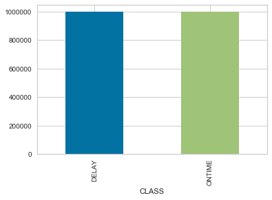

```python
df.groupby('CLASS').size().plot.bar()
```

# EDA - Further

## Top Arrival Airports & Airlines

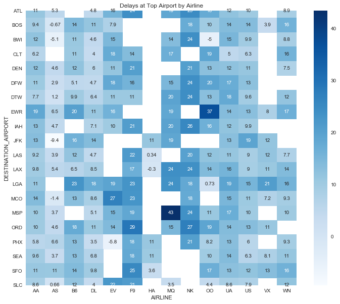

```python
top = 20
topAirports = df.groupby('DESTINATION_AIRPORT').size() \
    .sort_values(ascending=False) \
    .head(top) \
    .index \
    .tolist()

pvt = df[df.DESTINATION_AIRPORT.isin(topAirports)] \
    .groupby(['AIRLINE', 'DESTINATION_AIRPORT']) \
    .agg({'ARRIVAL_DELAY': 'mean'}) \
    .reset_index() \
    .pivot(index='DESTINATION_AIRPORT', columns='AIRLINE', values='ARRIVAL_DELAY')

plt.figure(figsize=(12,10))
plt.title('Delays at Top Airport by Airline')
sns.heatmap(pvt, cmap='Blues', annot=True)
plt.yticks(rotation=0)
```

## Airline Delay Distribution

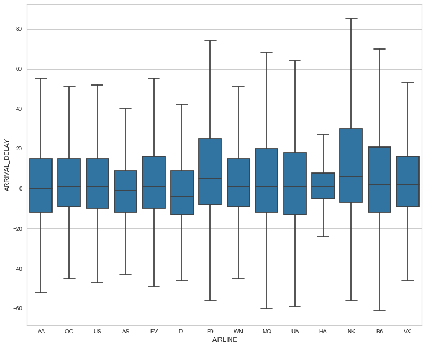

```python
plt.figure(figsize=(12,10))
sns.boxplot(x=df.AIRLINE,
            y=df.ARRIVAL_DELAY,
            showfliers=False,
            color='#1f77b4')
```

## Delays by Month

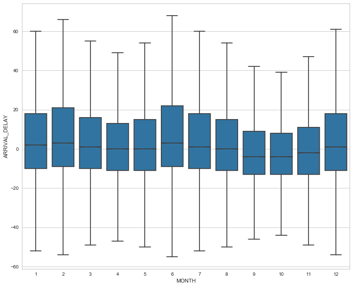

```python
plt.figure(figsize=(12,10))
sns.boxplot(x=df.MONTH,
            y=df.ARRIVAL_DELAY,
            showfliers=False,
            notch=True,
            color='#1f77b4')
```

## Delays by Day of Week

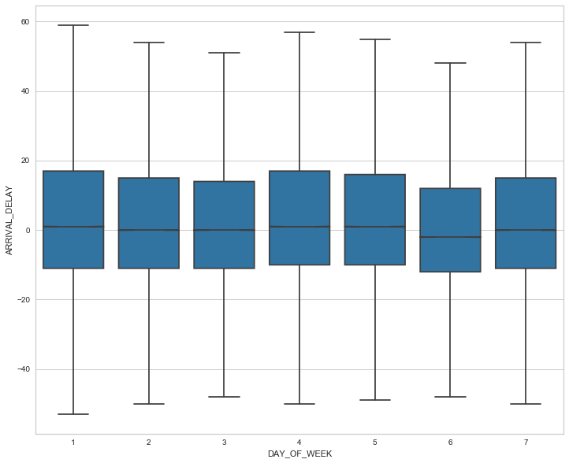

```python
plt.figure(figsize=(12,10))
sns.boxplot(x=df.DAY_OF_WEEK,
            y=df.ARRIVAL_DELAY,
            showfliers=False,
            notch=True,
            color='#1f77b4')
```

## Distance

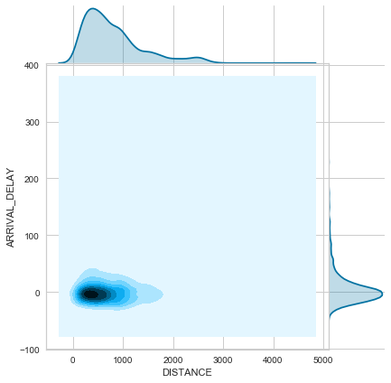

```python
plt.figure(figsize=(15,12))
deltaDF = df.sample(2000, random_state=5)
sns.jointplot('DISTANCE', 'ARRIVAL_DELAY', data=deltaDF, kind='kde', space=0, color='b')
```

## Scheduled Departure

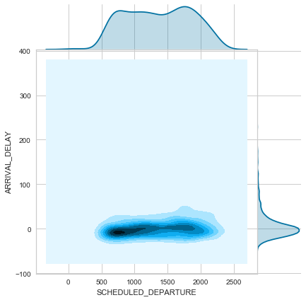

```python
plt.figure(figsize=(15,12))
deltaDF = df.sample(2000, random_state=5)
sns.jointplot('SCHEDULED_DEPARTURE', 'ARRIVAL_DELAY', data=deltaDF, kind='kde', space=0, color='b')
```

## Scheduled Arrival

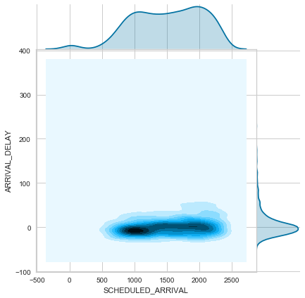

```python
plt.figure(figsize=(15,12))
deltaDF = df.sample(2000, random_state=5)
sns.jointplot('SCHEDULED_ARRIVAL', 'ARRIVAL_DELAY', data=deltaDF, kind='kde', space=0, color='b')
```

## Scheduled Time

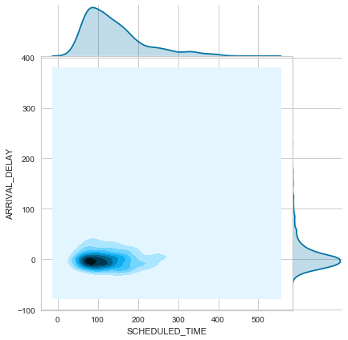

```python
plt.figure(figsize=(15,12))
deltaDF = df.sample(2000, random_state=5)
sns.jointplot('SCHEDULED_TIME', 'ARRIVAL_DELAY', data=deltaDF, kind='kde', space=0, color='b')
```

# Pipeline

```python
df.dtypes
```

```
MONTH                    int64
DAY_OF_WEEK              int64
AIRLINE                 object
ORIGIN_AIRPORT          object
DESTINATION_AIRPORT     object
SCHEDULED_DEPARTURE      int64
SCHEDULED_ARRIVAL        int64
SCHEDULED_TIME         float64
DISTANCE                 int64
ARRIVAL_DELAY          float64
CANCELLED                int64
CLASS                   object
dtype: object
```

```python
featuresNumeric = [
    'DISTANCE',
    'SCHEDULED_DEPARTURE',
    'SCHEDULED_ARRIVAL',
    'SCHEDULED_TIME'
]
transformerNumeric = Pipeline(steps=[
    ('imputer', SimpleImputer(strategy='median')),
    ('scaler',  StandardScaler())
], verbose=True)


featuresCategorical = [
    'MONTH',
    'DAY_OF_WEEK',
    'AIRLINE',
    'ORIGIN_AIRPORT',
    'DESTINATION_AIRPORT'
]
transformerCategorical = Pipeline(steps=[
    ('imputer', SimpleImputer(strategy='constant', fill_value='missing')),
    ('onehot',  OneHotEncoder(categories='auto', handle_unknown='ignore'))
], verbose=True)


preprocessor = ColumnTransformer(transformers=[
        ('num' , transformerNumeric,     featuresNumeric),
        ('cat' , transformerCategorical, featuresCategorical)
])
```

```python
X = df.copy()
X = X.sample(frac=0.25, random_state=23)
X.MONTH       = X.MONTH.astype(str)
X.DAY_OF_WEEK = X.DAY_OF_WEEK.astype(str)
X.AIRLINE     = X.AIRLINE.astype(str)
X.ORIGIN_AIRPORT      = X.ORIGIN_AIRPORT.astype(str)
X.DESTINATION_AIRPORT = X.DESTINATION_AIRPORT.astype(str)
print(X.dtypes)

y = X.CLASS
X = X.drop(['CLASS', 'CANCELLED', 'ARRIVAL_DELAY'], axis=1)
X_train, X_test, y_train, y_test = train_test_split(X, y, test_size=0.2)
y_train = np.where(y_train == 'ONTIME', 0, 1)
y_test  = np.where(y_test  == 'ONTIME', 0, 1)
```

```
MONTH                   object
DAY_OF_WEEK             object
AIRLINE                 object
ORIGIN_AIRPORT          object
DESTINATION_AIRPORT     object
SCHEDULED_DEPARTURE      int64
SCHEDULED_ARRIVAL        int64
SCHEDULED_TIME         float64
DISTANCE                 int64
ARRIVAL_DELAY          float64
CANCELLED                int64
CLASS                   object
dtype: object
```

# Metrics

```python
def measureErrors(y, y_hat):
    accuracy = accuracy_score(y, y_hat)
    print('Accuracy', accuracy)
    print('Confusion Matrix')
    print(confusion_matrix(y, yhat))
    print('Classification Report')
    print(classification_report(y_hat, y))
    return accuracy
```

```python
resultsDF = pd.DataFrame(columns=['Accuracy'])
```

# Bagging vs Boosting

- Bagging = Bootstrap Aggregating
  - Leverage high variance (overfitting) unstable learners
- Boosting
  - Combine high bias (underfitting) stable learnings

## Data

- Bagging - Each model pulls a random subsample of the entire dataset
- Boosting - Data is incrementally built giving more preference to misclassified datapoints

## Models

- Bagging
  - Each model gets an equal vote
  - Models can be built in parallel
- Boosting
  - Model is incrementally built
  - Model is sequentually built

https://bradzzz.gitbooks.io/ga-dsi-seattle/dsi/dsi_06_trees_methods/3.1-lesson/readme.html

# AdaBoost - Adaptive Boosting

## Weak Learner

- Deault = DecisionTreeClassifier(max_depth=1)
- Best split chosen based on Information Gain
  - Parent Entropy - Mean(Child Entropy)
- Plug in your own (SVC for example)
- Ever played Guess Who?

## Convergence

- After n Rounds of boosting
- Early Stopping

## Fit Model

```python
ada = AdaBoostClassifier(n_estimators=50)
pipe = Pipeline([('pp', preprocessor),
                ('classifier', ada)])
pipe.fit(X_train, y_train)
```

```
[Pipeline] ........... (step 1 of 2) Processing imputer, total=   0.2s
[Pipeline] ............ (step 2 of 2) Processing scaler, total=   0.0s
[Pipeline] ........... (step 1 of 2) Processing imputer, total=   0.3s
[Pipeline] ............ (step 2 of 2) Processing onehot, total=   1.0s
```

```
Pipeline(memory=None,
         steps=[('pp',
                 ColumnTransformer(n_jobs=None, remainder='drop',
                                   sparse_threshold=0.3,
                                   transformer_weights=None,
                                   transformers=[('num',
                                                  Pipeline(memory=None,
                                                           steps=[('imputer',
                                                                   SimpleImputer(add_indicator=False,
                                                                                 copy=True,
                                                                                 fill_value=None,
                                                                                 missing_values=nan,
                                                                                 strategy='median',
                                                                                 verbose=0)),
                                                                  ('scaler',
                                                                   StandardScaler(copy=True,
                                                                                  with_mean=True,
                                                                                  with...
                                                                                 categories='auto',
                                                                                 drop=None,
                                                                                 dtype=<class 'numpy.float64'>,
                                                                                 handle_unknown='ignore',
                                                                                 n_values=None,
                                                                                 sparse=True))],
                                                           verbose=True),
                                                  ['MONTH', 'DAY_OF_WEEK',
                                                   'AIRLINE', 'ORIGIN_AIRPORT',
                                                   'DESTINATION_AIRPORT'])],
                                   verbose=False)),
                ('classifier',
                 AdaBoostClassifier(algorithm='SAMME.R', base_estimator=None,
                                    learning_rate=1.0, n_estimators=50,
                                    random_state=None))],
         verbose=False)
```

## Predict

```python
yhat = pipe.predict(X_test)
```

## Score Model

```python
acc = measureErrors(y_test, yhat)
resultsDF.loc['AdaBoost'] = [acc]
```

```
Accuracy 0.58339
Confusion Matrix
[[27647 22244]
 [19417 30692]]
Classification Report
              precision    recall  f1-score   support

           0       0.55      0.59      0.57     47064
           1       0.61      0.58      0.60     52936

    accuracy                           0.58    100000
   macro avg       0.58      0.58      0.58    100000
weighted avg       0.59      0.58      0.58    100000
```

## Visualize

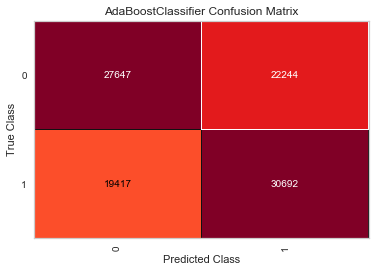

```python
visualizer = ConfusionMatrix(pipe, is_fitted=True)
visualizer.score(X_test, y_test)
visualizer.poof()
```

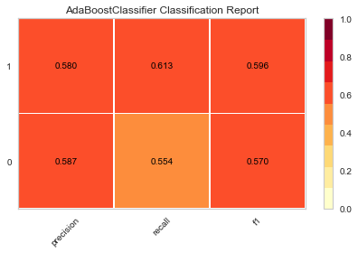

```python
visualizer = ClassificationReport(pipe, is_fitted=True)
visualizer.score(X_test, y_test)
visualizer.poof()
```

# AdaBoost in Action

# XGBoost - eXtreme Gradient Boosting

- XGBoost became the top kaggle algorithm for structured data
- Features
  - Automatic handling of missing data
  - Built in cross-validation
  - Regularization to avoid overfitting
  - Parallel building
  - Customized loss functions
- Variety of Problems
  - Classification
  - Regression
  - Ranking

## Loss Function + Regularization

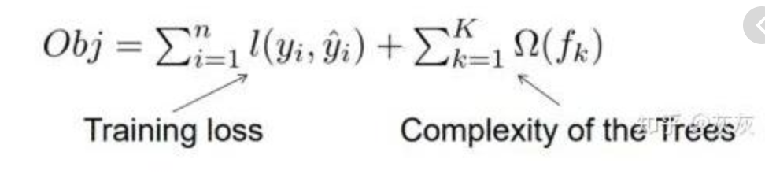

## Tree Complexity

- Max Depth to control complexity
- Trees typically built level-wise
- Practical Advice
  - 3 or 5 is usually sufficient
  - Good parameter to hypertune
  - Have heard of using very large depth trees (30+)

## Histogram Tree Building

- Finding the optimal split is time conumsing
  - Proportional to number of splits
  - But, small changes in split don't make big changes in performance
- Split features into bins & check splits on bins
- Tradeoff
  - Small number of bins = Faster, Less Accurate
  - Large number of bins (@ limit = bin per split) = Slower, More Accurate
- Finding the correct binning
  - Trivial binning (equal interval) will often be unbalanced
  - Exact : identify best split
  - Approx : tree-method will compute new bins on each split
  - Hist : tree-method will compute bins once & reuse
  - Auto : Depends on dagtaset
    - Small -> Exact
    - Large -> Approx
- Hist building reduces BigO

## Gradient

## Learning Rate

- Large learning rates
  - 1.0 considered large / full step on gradient
  - Faster convergence
  - Overshoot or miss minima
- Smaller learning rate
  - Slower to converge
  - More likely to find good minima
  - Advice - smallest learning rate you can tolerate

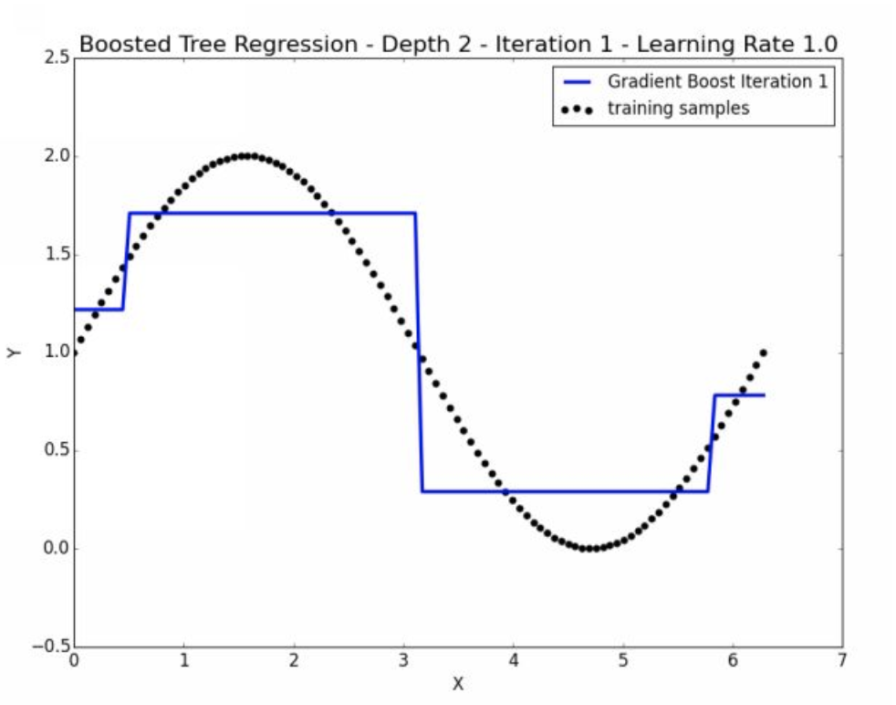

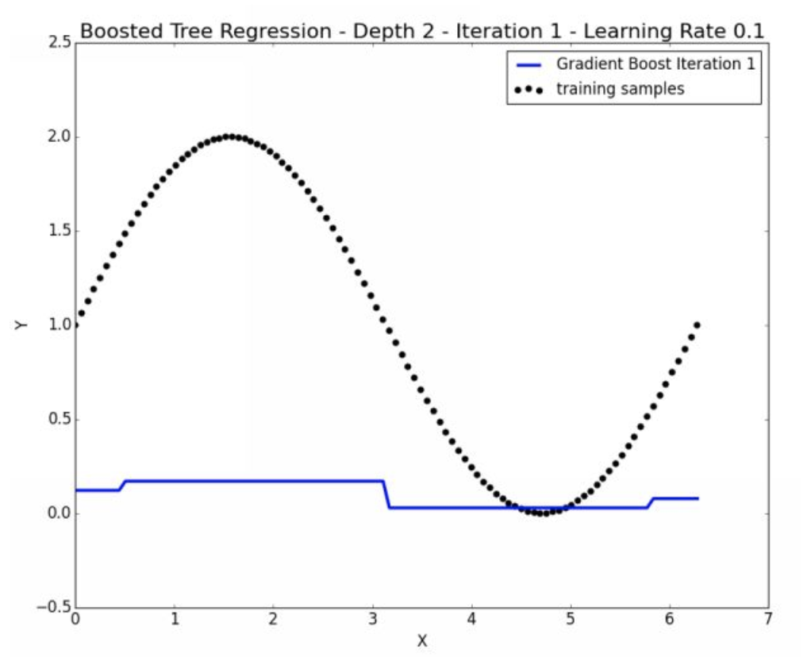

## Fit Model

```python
bst = xgb.XGBRegressor(n_estimators=10000,
                       max_depth=10,
                       objective='binary:logistic',
                       learning_rate=0.1,
                       tree_method='auto',
                       verbosity=1)
```

```python
X_train_xgb, X_val_xgb, y_train_xgb, y_val_xgb = train_test_split(X_train, y_train, test_size=0.2, random_state=1337)
```

```python
pipe = Pipeline(steps=[('preprocess', preprocessor)])
X_prep_train = pipe.fit_transform(X_train_xgb, y_train_xgb)
X_prep_val   = pipe.transform(X_val_xgb)
X_prep_test  = pipe.transform(X_test)
```

```
[Pipeline] ........... (step 1 of 2) Processing imputer, total=   0.2s
[Pipeline] ............ (step 2 of 2) Processing scaler, total=   0.0s
[Pipeline] ........... (step 1 of 2) Processing imputer, total=   0.2s
[Pipeline] ............ (step 2 of 2) Processing onehot, total=   0.8s
```

```python
eval_set = [(X_prep_val, y_val_xgb)]
bst.fit(X_prep_train, y_train_xgb,
        early_stopping_rounds=5,
        eval_metric=['logloss'],
        eval_set=eval_set,
        verbose=True)
```

[output not shown]

```
XGBRegressor(base_score=0.5, booster='gbtree', colsample_bylevel=1,
             colsample_bytree=1, gamma=0, importance_type='gain',
             learning_rate=0.1, max_delta_step=0, max_depth=10,
             min_child_weight=1, missing=None, n_estimators=10000, n_jobs=1,
             nthread=None, objective='binary:logistic', random_state=0,
             reg_alpha=0, reg_lambda=1, scale_pos_weight=1, seed=None,
             silent=True, subsample=1, tree_method='auto', verbosity=1)
```

## Predict

```python
pred  = bst.predict(X_prep_test, bst.best_iteration)
proba = np.exp(pred) / (1 + np.exp(pred))
yhat  = np.where(proba > 0.5, 1, 0)
```

## Score Model

```python
acc = measureErrors(y_test, yhat)
resultsDF.loc['XGBoost'] = [acc]
```

```
Accuracy 0.60834
Confusion Matrix
[[29631 20260]
 [18906 31203]]
Classification Report
              precision    recall  f1-score   support

           0       0.59      0.61      0.60     48537
           1       0.62      0.61      0.61     51463

    accuracy                           0.61    100000
   macro avg       0.61      0.61      0.61    100000
weighted avg       0.61      0.61      0.61    100000
```

# LightGBM

- Relevant Papers / Blogs
  - https://papers.nips.cc/paper/6907-lightgbm-a-highly-efficient-gradient-boosting-decision-tree.pdf
  - https://mlexplained.com/2018/01/05/lightgbm-and-xgboost-explained/
- **Faster Training Time**
  - Gradient-Based One Side Sampling (GOSS)
  - Exclusive Feature Bundling
- Categorical Handling
  - Label Encode for better performance
  - Support for missing values
- Parallel Improvements
  - Feature Parallel
  - Data Parallel

## LightGBM

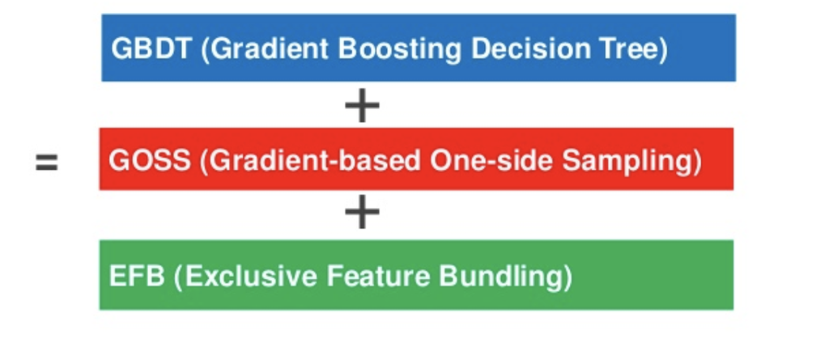

## Tree

- Level-wise
  - Constraint creates a balanced tree
  - A form of regularization (can't grow deep)
  - XGBoost default (switch with the hist tree-method)
  - Not available in lightGBM
- Leaf-wise
  - Creates splits that reduce loss the most (i.e. biggest info gain)
  - More prone to overfit
  - More flexible
- Know your tree policy when applying level or leaf
  - num_leaves & max_depth
  - Restricting leaves can still lead to a deep tree with leaf-wise growth

## Gradient One-Sided Sampling

- How do we subsample the data?

## Exclusive Feature Bundling

- Reduce Big O complexity
  - From O(Features * Data)
  - To O(Features * Bundled Data)
- Mutually exclusive features can be combined
- In practice, we encounter this frequently
  - For example : No flights from PDX to SVO

## Fit Model

```python
pipe = Pipeline([('pp', preprocessor),
                ('classifier', lgb.LGBMClassifier())])
```

```python
pipe.fit(X_train, y_train,
         classifier__verbose=True)
```

```
[Pipeline] ........... (step 1 of 2) Processing imputer, total=   0.3s
[Pipeline] ............ (step 2 of 2) Processing scaler, total=   0.0s
[Pipeline] ........... (step 1 of 2) Processing imputer, total=   0.3s
[Pipeline] ............ (step 2 of 2) Processing onehot, total=   1.0s
```

```
Pipeline(memory=None,
         steps=[('pp',
                 ColumnTransformer(n_jobs=None, remainder='drop',
                                   sparse_threshold=0.3,
                                   transformer_weights=None,
                                   transformers=[('num',
                                                  Pipeline(memory=None,
                                                           steps=[('imputer',
                                                                   SimpleImputer(add_indicator=False,
                                                                                 copy=True,
                                                                                 fill_value=None,
                                                                                 missing_values=nan,
                                                                                 strategy='median',
                                                                                 verbose=0)),
                                                                  ('scaler',
                                                                   StandardScaler(copy=True,
                                                                                  with_mean=True,
                                                                                  with...
                 LGBMClassifier(boosting_type='gbdt', class_weight=None,
                                colsample_bytree=1.0, importance_type='split',
                                learning_rate=0.1, max_depth=-1,
                                min_child_samples=20, min_child_weight=0.001,
                                min_split_gain=0.0, n_estimators=100, n_jobs=-1,
                                num_leaves=31, objective=None,
                                random_state=None, reg_alpha=0.0,
                                reg_lambda=0.0, silent=True, subsample=1.0,
                                subsample_for_bin=200000, subsample_freq=0))],
         verbose=False)
```

## Predict

```python
pred = pipe.predict(X_test)
```

## Score Model

```python
acc = measureErrors(y_test, pred)
resultsDF.loc['LightGBM'] = acc
```

```
Accuracy 0.60427
Confusion Matrix
[[29631 20260]
 [18906 31203]]
Classification Report
              precision    recall  f1-score   support

           0       0.60      0.61      0.60     49056
           1       0.61      0.60      0.61     50944

    accuracy                           0.60    100000
   macro avg       0.60      0.60      0.60    100000
weighted avg       0.60      0.60      0.60    100000
```

# CatBoost

- Features good default parameter values (avoid hypertuning)
- **Categorical support** (think R categories - no need to OHE)
- Scalable GPU learning
- Uses a novel gradient boosting scheme to improve accuracy
- Overfitting detector (early stop)
- **Fast predictions**

## Algorithm

- https://towardsdatascience.com/https-medium-com-talperetz24-mastering-the-new-generation-of-gradient-boosting-db04062a7ea2

## Categorical Features

### Ordered Target Statistic

- Makes use of target mean encoding
- Fights "leakage" of target into features
- Order observations, use seen history to estimate target

### One Hot Encoding

- CatBoost automatically handles categorical -> one hot
- Controlled with the one_hot_max_size
- Do **not** one hot encode in preprocessing

### Ordered Boosting

## Key Hyperparameters

- Cat Features - Indication of categorical features in dataset
- One Hot Max Size - Max number of indicators to create a one hot column
- Learning Rate - Step size in direction of gradient
- Num Estimators - Rounds of boosting (if not early stopping)

## Fit Model

```python
catModel = cat.CatBoostClassifier(iterations=500,
                          depth=6,
                          learning_rate=0.1,
                          early_stopping_rounds=5,
                          loss_function='Logloss')
```

```python
X_train_cb, X_val_cb, y_train_cb, y_val_cb = \
    train_test_split(X_train, y_train, test_size=0.2, random_state=1337)
```

```python
cat_idx = X_train_cb.columns.get_indexer(X_train_cb.select_dtypes('object').columns)

train_pool = cat.Pool(X_train_cb, y_train_cb, cat_features=cat_idx)
val_pool   = cat.Pool(X_val_cb, y_val_cb, cat_features=cat_idx)
test_pool  = cat.Pool(X_test, cat_features=cat_idx)
```

```python
catModel.fit(train_pool, eval_set=val_pool)
```

```
0:	learn: 0.6896350	test: 0.6897463	best: 0.6897463 (0)	total: 303ms	remaining: 2m 31s
1:	learn: 0.6865389	test: 0.6867260	best: 0.6867260 (1)	total: 487ms	remaining: 2m 1s
2:	learn: 0.6840035	test: 0.6843028	best: 0.6843028 (2)	total: 684ms	remaining: 1m 53s
3:	learn: 0.6816588	test: 0.6818821	best: 0.6818821 (3)	total: 991ms	remaining: 2m 2s
4:	learn: 0.6796994	test: 0.6799007	best: 0.6799007 (4)	total: 1.21s	remaining: 1m 59s
5:	learn: 0.6779084	test: 0.6780865	best: 0.6780865 (5)	total: 1.42s	remaining: 1m 57s
6:	learn: 0.6763846	test: 0.6764969	best: 0.6764969 (6)	total: 1.65s	remaining: 1m 56s
7:	learn: 0.6750987	test: 0.6751676	best: 0.6751676 (7)	total: 1.94s	remaining: 1m 59s
8:	learn: 0.6738897	test: 0.6738814	best: 0.6738814 (8)	total: 2.12s	remaining: 1m 55s
9:	learn: 0.6728262	test: 0.6728134	best: 0.6728134 (9)	total: 2.29s	remaining: 1m 52s
10:	learn: 0.6719624	test: 0.6719293	best: 0.6719293 (10)	total: 2.48s	remaining: 1m 50s
11:	learn: 0.6712313	test: 0.6711886	best: 0.6711886 (11)	total: 2.69s	remaining: 1m 49s
12:	learn: 0.6704805	test: 0.6704838	best: 0.6704838 (12)	total: 2.95s	remaining: 1m 50s
13:	learn: 0.6697082	test: 0.6696710	best: 0.6696710 (13)	total: 3.24s	remaining: 1m 52s
14:	learn: 0.6690405	test: 0.6689971	best: 0.6689971 (14)	total: 3.55s	remaining: 1m 54s
15:	learn: 0.6684814	test: 0.6684415	best: 0.6684415 (15)	total: 3.82s	remaining: 1m 55s
16:	learn: 0.6679537	test: 0.6679307	best: 0.6679307 (16)	total: 4.07s	remaining: 1m 55s
17:	learn: 0.6674736	test: 0.6674009	best: 0.6674009 (17)	total: 4.29s	remaining: 1m 54s
18:	learn: 0.6670411	test: 0.6670018	best: 0.6670018 (18)	total: 4.5s	remaining: 1m 53s
19:	learn: 0.6666871	test: 0.6666476	best: 0.6666476 (19)	total: 4.71s	remaining: 1m 53s
20:	learn: 0.6663238	test: 0.6662992	best: 0.6662992 (20)	total: 4.98s	remaining: 1m 53s
21:	learn: 0.6658998	test: 0.6658626	best: 0.6658626 (21)	total: 5.24s	remaining: 1m 53s
22:	learn: 0.6655631	test: 0.6654797	best: 0.6654797 (22)	total: 5.46s	remaining: 1m 53s
23:	learn: 0.6652960	test: 0.6652181	best: 0.6652181 (23)	total: 5.64s	remaining: 1m 51s
24:	learn: 0.6650045	test: 0.6648997	best: 0.6648997 (24)	total: 5.86s	remaining: 1m 51s
25:	learn: 0.6646250	test: 0.6644915	best: 0.6644915 (25)	total: 6.12s	remaining: 1m 51s
26:	learn: 0.6643916	test: 0.6642819	best: 0.6642819 (26)	total: 6.36s	remaining: 1m 51s
27:	learn: 0.6640249	test: 0.6638499	best: 0.6638499 (27)	total: 6.64s	remaining: 1m 51s
28:	learn: 0.6638064	test: 0.6635832	best: 0.6635832 (28)	total: 6.89s	remaining: 1m 51s
29:	learn: 0.6635954	test: 0.6633674	best: 0.6633674 (29)	total: 7.15s	remaining: 1m 52s
30:	learn: 0.6633986	test: 0.6631484	best: 0.6631484 (30)	total: 7.49s	remaining: 1m 53s
31:	learn: 0.6632570	test: 0.6630454	best: 0.6630454 (31)	total: 7.77s	remaining: 1m 53s
32:	learn: 0.6631180	test: 0.6628880	best: 0.6628880 (32)	total: 8.04s	remaining: 1m 53s
33:	learn: 0.6629393	test: 0.6626819	best: 0.6626819 (33)	total: 8.3s	remaining: 1m 53s
34:	learn: 0.6627641	test: 0.6625056	best: 0.6625056 (34)	total: 8.52s	remaining: 1m 53s
35:	learn: 0.6626731	test: 0.6624116	best: 0.6624116 (35)	total: 8.75s	remaining: 1m 52s
36:	learn: 0.6625119	test: 0.6622582	best: 0.6622582 (36)	total: 8.96s	remaining: 1m 52s
37:	learn: 0.6622510	test: 0.6619133	best: 0.6619133 (37)	total: 9.24s	remaining: 1m 52s
38:	learn: 0.6621437	test: 0.6618252	best: 0.6618252 (38)	total: 9.44s	remaining: 1m 51s
39:	learn: 0.6619390	test: 0.6615958	best: 0.6615958 (39)	total: 9.63s	remaining: 1m 50s
```

[output cut: 450 more lines]

```
490:	learn: 0.6466579	test: 0.6519558	best: 0.6519558 (490)	total: 1m 48s	remaining: 1.99s
491:	learn: 0.6466324	test: 0.6519520	best: 0.6519520 (491)	total: 1m 48s	remaining: 1.76s
492:	learn: 0.6466166	test: 0.6519502	best: 0.6519502 (492)	total: 1m 48s	remaining: 1.54s
493:	learn: 0.6466013	test: 0.6519403	best: 0.6519403 (493)	total: 1m 48s	remaining: 1.32s
494:	learn: 0.6465797	test: 0.6519330	best: 0.6519330 (494)	total: 1m 49s	remaining: 1.1s
495:	learn: 0.6465662	test: 0.6519248	best: 0.6519248 (495)	total: 1m 49s	remaining: 882ms
496:	learn: 0.6465423	test: 0.6519165	best: 0.6519165 (496)	total: 1m 49s	remaining: 662ms
497:	learn: 0.6465249	test: 0.6519246	best: 0.6519165 (496)	total: 1m 49s	remaining: 441ms
498:	learn: 0.6465105	test: 0.6519278	best: 0.6519165 (496)	total: 1m 50s	remaining: 221ms
499:	learn: 0.6464975	test: 0.6519202	best: 0.6519165 (496)	total: 1m 50s	remaining: 0us

bestTest = 0.6519164915
bestIteration = 496

Shrink model to first 497 iterations.
```

```
<catboost.core.CatBoostClassifier at 0x13797e3c8>
```

## Predict

```python
pred = catModel.predict(test_pool)
```

## Score Model

```python
acc = measureErrors(pred, y_test)
resultsDF.loc['CatBoost'] = [acc]
```

```
Accuracy 0.61573
Confusion Matrix
[[42137  7453]
 [ 6400 44010]]
Classification Report
              precision    recall  f1-score   support

           0       0.62      0.61      0.61     49891
           1       0.62      0.62      0.62     50109

    accuracy                           0.62    100000
   macro avg       0.62      0.62      0.62    100000
weighted avg       0.62      0.62      0.62    100000
```

## Importance

```python
importanceDF = pd.DataFrame(columns=['Feature', 'Importance'])
importanceDF['Feature'] = X_train_cb.columns
importanceDF['Importance'] = catModel.feature_importances_
importanceDF = importanceDF.sort_values('Importance', ascending=False)
importanceDF
```

|  | Feature | Importance |
| --- | --- | --- |
| 5 | SCHEDULED_DEPARTURE | 16.082780 |
| 0 | MONTH | 15.302733 |
| 2 | AIRLINE | 14.798640 |
| 3 | ORIGIN_AIRPORT | 11.506801 |
| 4 | DESTINATION_AIRPORT | 11.124715 |
| 6 | SCHEDULED_ARRIVAL | 9.440691 |
| 7 | SCHEDULED_TIME | 7.622457 |
| 1 | DAY_OF_WEEK | 7.073152 |
| 8 | DISTANCE | 7.048030 |

```
<BarContainer object of 9 artists>
```

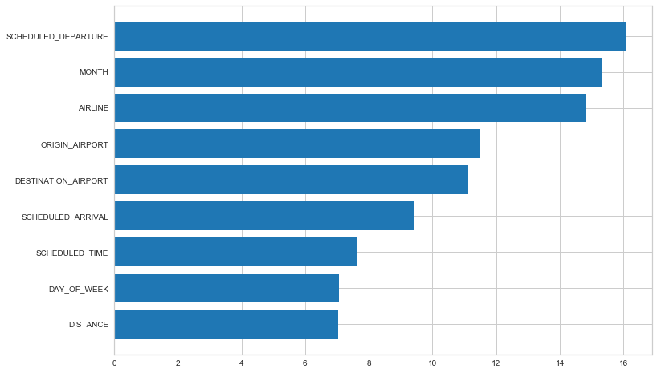

```python
plt.figure(figsize=(12,8))
importanceDF = importanceDF.sort_values('Importance', ascending=True)
plt.barh(importanceDF.Feature, importanceDF.Importance, color='#1f77b4')
```

# Comparison

- We're beating a random coin, but this is not a terribly accurate model
- Consider feature engineering
  - Interactions
  - Routes
- Model Approach
  - Is one model for all airports great?
  - Departure or Arrival Airport Model
  - Airline Model
  - Ensemble

```python
resultsDF.sort_values('Accuracy', ascending=False)
```

|  | Accuracy |
| --- | --- |
| CatBoost | 0.61573 |
| XGBoost | 0.60834 |
| LightGBM | 0.60427 |
| AdaBoost | 0.58339 |

# Tips & Tricks

- Boosting needs to be in your machine learning techniques
- There is variety with LightGBM and CatBoost
- Know your trees!
  - Outliers hurt boosting
  - Consider interactions
- Feature Importances
  - Can be used to feature select